# R Notebook - Analytics Zone

Group YoutubeFinder

> This RMarkdown represents the Analytics Zone and consists of the analysis that has been done in the Transcriptions files.

# Text Mining: Generate the WordCloud for the Raw Transcripts (data from HDFS)

```r
# Importing the different libraries
# The Reticulate package purposes is to connect to Python script. We built a Python script to transform the vtt format to plain text.
library("reticulate")
library("readtext")
library("NLP")
library("tm")
library("RColorBrewer")
library("wordcloud")
library("wordcloud2")
library("dplyr")
library("tidyr")

root_path <- "/Users/daniel/LocalFiles for TFM/"
setwd(root_path)
```

# Reading and formatting the file

```r
#DATA_DIR <- system.file(root_path,package = "readtext")
file_df <- readtext(paste0(root_path,"Files/ALL_Transcripts/*.txt"))
#file_df<- data.frame(file)
# Drop doc_id column
file_df<- subset(file_df,select = -c(doc_id))
file_df<- data.frame(Text = file_df)
head(file_df)
```

[output not shown]

# Process to clean up the text

```r
print("Removing backslash")
file_df_collapse<-gsub("\\\\","",file_df)
head(file_df_collapse)

print("To lower case")
file_df_collapse_lower <- tolower(file_df_collapse)
head(file_df_collapse_lower)
#Remove punctuation
print("Removing punctuation")
file_df_collapse_lower_rp <- gsub(pattern = "\\W", " ", file_df_collapse_lower)
#Remove digit
print("Removing digit")
file_df_collapse_lower_rp_rd <- gsub(pattern = "\\d", " ", file_df_collapse_lower_rp)

# stopwords()
#print("Removing stop words")
#file_df_collapse_lower_rp_rd_sw <- removeWords(file_df_collapse_lower_rp_rd, words = stopwords("english"))

# Remove single letters
print("Removing single letters")
file_df_collapse_lower_rp_rd_sw_sl <- gsub(pattern = "\\b[A-z]\\b{1}"," ", file_df_collapse_lower_rp_rd)

# Remove white spaces using stripWhitespace() function,which is a part of  tm library.
print("Removing white spaces")
file_df_collapse_lower_rp_rd_sw_sl_stp <- stripWhitespace(file_df_collapse_lower_rp_rd_sw_sl)
```

[output not shown]

# Frequency of words:

```r
# Split individual words and add space between them
print("Processing frequency words")
file_df_collapse_lower_rp_rd_sw_sl_stp_f <- strsplit(file_df_collapse_lower_rp_rd_sw_sl_stp, " ")
head(file_df_collapse_lower_rp_rd_sw_sl_stp_f)

# Creation of word frequency
word_freq <- table(file_df_collapse_lower_rp_rd_sw_sl_stp_f)
head(word_freq)

word_freq1 <- cbind(names(word_freq),as.integer(word_freq))
head(word_freq1)
```

[output not shown]

# General Information about WordCloud:

The feature of words can be illustrated as a word cloud as follow: * Word clouds add clarity and simplicity. * The most used keywords stand out better in a word cloud. * Word clouds are a dynamic tool for communication. Easy to understand, to be shared and are impressive words representation.

- Parameters:
  - **words**: the words to be plotted i.e; word_cloud where we have saved the text-data.
  - **Freq**: word frequencies
  - **min.freq**: words with a frequency below min.freq will not be plotted.
  - **max .words**: maximum number of words to be plotted
  - **random.order**: plot words in random order. If false, then words will be plotted in decreasing frequency
  - **Rot.per**: to adjust proportion words with 90-degree rotation (vertical text)
  - **colors**: color words from least to most frequent. Use, for example, colors =“Red” for a single color or “random-dark”, “random-light”.

```r
print("Processing Word Cloud")
word_cloud <- unlist(file_df_collapse_lower_rp_rd_sw_sl_stp_f)
#Option 1
wordcloud(word_cloud,min.freq = 50, max.words=500, random.order=F, rot.per=0.2, colors=brewer.pal(5, "Dark2"), scale=c(4,0.2))
#Option 2
wordcloud2(word_freq,color = "random-dark", backgroundColor = "white",size = 0.7)
```

[output not shown]

# Wordcloud per Category:

In this secion we prepare the wordcloud for the transcripts per each different category selected for the project: - Beauty and Fitness; - Book and Literature; - Business and Industrial; - Computers and Electronics; - Food and Drink.

```r
file_df_cat <- readtext(paste0(root_path,"Files/ALL_Transcripts/*.txt"))
#Replacing the pattern .en.txt in the doc_id column
file_df_cat$doc_id<- gsub(pattern = ".en.txt",replacement = "",file_df_cat$doc_id)
class(file_df_cat)
```

```
[1] "readtext"   "data.frame"
```

```
readtext

data.frame
```

```r
head(file_df_cat)
```

|  | doc_id | text |
| --- | --- | --- |
| 1 | --6kQuiAEjI | hello everyone in a previous video I showed you how to make a hole in a\nthreaded rod or a screw well in this case it is a piece of\nrod or in this case an s but it is smooth therefore I can not take … |
| 2 | --7pVHGDdYI | yeah right on time right on time so beautiful day for celebration hello\nthere good morning ladies and gentlemen and welcome to this truly momentous\noccasion in a few moments yeah in a few moments th… |
| 3 | --BrlAsOeUY | hello everyone welcome to be review 850 communicator the master of puppets they\nand joined by knock up a lot of malts and today we're going to be looking at a\nreally special beer I can't wait to hav… |
| 4 | --Dvs2BwOI0 | with its treble clef to sunat we go and within this we have yes\nelectronic books and records there is no possibility of doing it\nthrough keys or it would imply that you\nbuy the rents or if not do n… |
| 5 | --EPFZnfHK8 | hi everyone welcome to my channel I'm back with another lipstick review and\nlive swatches today I'm going to talk about else lipsticks from the essential\nline these lipsticks are amazing and budget-… |
| 6 | --Hfol2AEOk | you talking about shoe positioning today\nwe're in the first week of June actually it's June 8th today and see we've got a\nfairly high canopy and what we're doing in this vineyard is what's called a\… |

```r
#Assigning the correct category for the specific video id
beauty_fitness <- read.delim(paste0(root_path,"Files/Beauty_Fitness.txt"),header=FALSE,sep=" ",dec=" ")
books_literature <- read.delim(paste0(root_path,"Files/Books_Literature.txt"),header=FALSE,sep=" ",dec=" ")
business_industrial <- read.delim(paste0(root_path,"Files/Business_Industrial.txt"),header=FALSE,sep=" ",dec=" ")
computers_electronics <- read.delim(paste0(root_path,"Files/Computers_Electronics.txt"),header=FALSE,sep=" ",dec=" ")
food_drink <- read.delim(paste0(root_path,"Files/Food_Drink.txt"),header=FALSE,sep=" ",dec=" ")
file_df_cat2 <- file_df_cat

file_df_cat2$category <- NA_character_
file_df_cat2 <- file_df_cat2 %>% mutate(category=ifelse(doc_id %in% beauty_fitness$V1,paste("Beauty and Fitness"),category)) %>%
    mutate(category=ifelse(doc_id %in% books_literature$V1,paste("Books and Literature"),category)) %>%
    mutate(category=ifelse(doc_id %in% business_industrial$V1,paste("Business and Industrial"),category)) %>%
    mutate(category=ifelse(doc_id %in% computers_electronics$V1,paste("Computers and Electronics"),category)) %>%
    mutate(category=ifelse(doc_id %in% food_drink$V1,paste("Food and Drink"),category)) %>%
  filter(category != "NA")

file_df_beauty_fitness <- file_df_cat2 %>% filter(category == "Beauty and Fitness")
file_df_books_literature <- file_df_cat2 %>% filter(category == "Books and Literature")
file_df_business_industrial <- file_df_cat2 %>% filter(category == "Business and Industrial")
file_df_computers_electronics <- file_df_cat2 %>% filter(category == "Computers and Electronics")
file_df_food_drink <- file_df_cat2 %>% filter(category == "Food and Drink")
```

## Clean up all the files prior to Wordcloud

```r
preProcessWordCloudFunction <- function(file_df){
    print("Removing backslash")
    file_df_collapse<-gsub("\\\\","",file_df)
    head(file_df_collapse)

    print("To lower case")
    file_df_collapse_lower <- tolower(file_df_collapse)
    head(file_df_collapse_lower)
    #Remove punctuation
    print("Removing punctuation")
    file_df_collapse_lower_rp <- gsub(pattern = "\\W", " ", file_df_collapse_lower)
    #Remove digit
    print("Removing digit")
    file_df_collapse_lower_rp_rd <- gsub(pattern = "\\d", " ", file_df_collapse_lower_rp)

    # stopwords()
    print("Removing stop words")
    file_df_collapse_lower_rp_rd_sw <- removeWords(file_df_collapse_lower_rp_rd, words = stopwords("english"))

    # Remove single letters
    print("Removing single letters")
    file_df_collapse_lower_rp_rd_sw_sl <- gsub(pattern = "\\b[A-z]\\b{1}"," ", file_df_collapse_lower_rp_rd_sw)

    # Remove white spaces using stripWhitespace() function,which is a part of  tm library.
    print("Removing white spaces")
    file_df_collapse_lower_rp_rd_sw_sl_stp <- stripWhitespace(file_df_collapse_lower_rp_rd_sw_sl)

    return(file_df_collapse_lower_rp_rd_sw_sl_stp)
}

file_df_beauty_fitness <- preProcessWordCloudFunction(file_df_beauty_fitness)
```

```
[1] "Removing backslash"
[1] "To lower case"
[1] "Removing punctuation"
[1] "Removing digit"
[1] "Removing stop words"
[1] "Removing single letters"
[1] "Removing white spaces"
```

```r
file_df_books_literature <- preProcessWordCloudFunction(file_df_books_literature)
```

```
[1] "Removing backslash"
[1] "To lower case"
[1] "Removing punctuation"
[1] "Removing digit"
[1] "Removing stop words"
[1] "Removing single letters"
[1] "Removing white spaces"
```

```r
file_df_business_industrial <- preProcessWordCloudFunction(file_df_business_industrial)
```

```
[1] "Removing backslash"
[1] "To lower case"
[1] "Removing punctuation"
[1] "Removing digit"
[1] "Removing stop words"
[1] "Removing single letters"
[1] "Removing white spaces"
```

```r
file_df_computers_electronics <- preProcessWordCloudFunction(file_df_computers_electronics)
```

```
[1] "Removing backslash"
[1] "To lower case"
[1] "Removing punctuation"
[1] "Removing digit"
[1] "Removing stop words"
[1] "Removing single letters"
[1] "Removing white spaces"
```

```r
file_df_food_drink <- preProcessWordCloudFunction(file_df_food_drink)
```

```
[1] "Removing backslash"
[1] "To lower case"
[1] "Removing punctuation"
[1] "Removing digit"
[1] "Removing stop words"
[1] "Removing single letters"
[1] "Removing white spaces"
```

## Wordcloud for Beauty and Fitness category

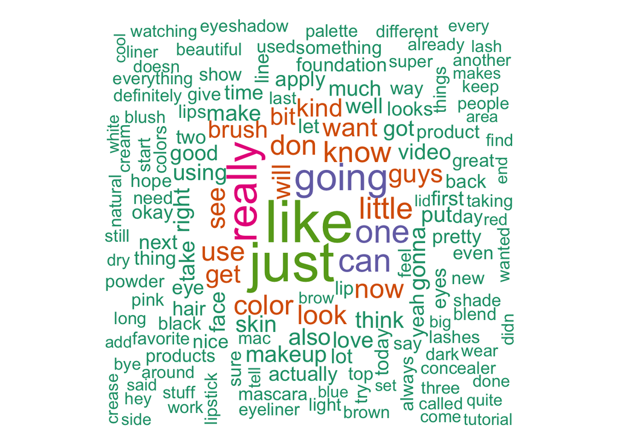

```r
file_df_beauty_fitness_freq <- strsplit(file_df_beauty_fitness, " ")
word_cloud_beauty_fit <- unlist(file_df_beauty_fitness_freq)

wordcloud(word_cloud_beauty_fit,min.freq = 50, max.words=200, random.order=F, rot.per=0.2, colors=brewer.pal(5, "Dark2"), scale=c(4,1))
```

## Wordcloud for Books and Literature category

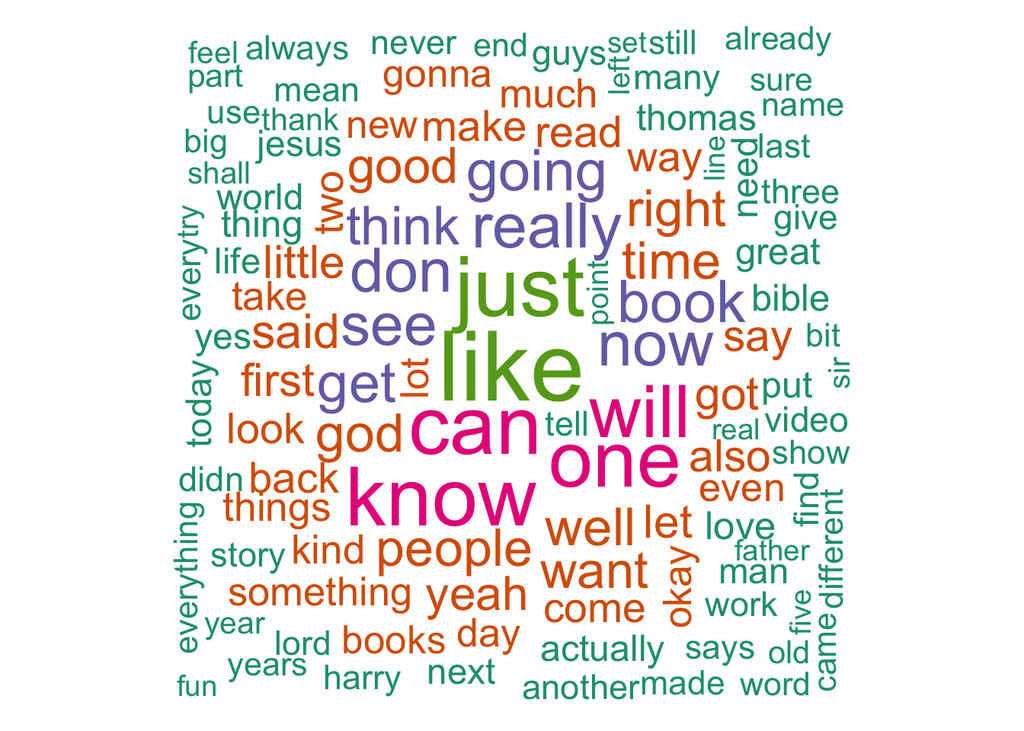

```r
file_df_books_literature_freq <- strsplit(file_df_books_literature, " ")
word_cloud_books_literature <- unlist(file_df_books_literature_freq)
#Option 1
wordcloud(word_cloud_books_literature,min.freq = 50, max.words=200, random.order=F, rot.per=0.2, colors=brewer.pal(5, "Dark2"), scale=c(4,1))
```

## Wordcloud for Business and Industrial category

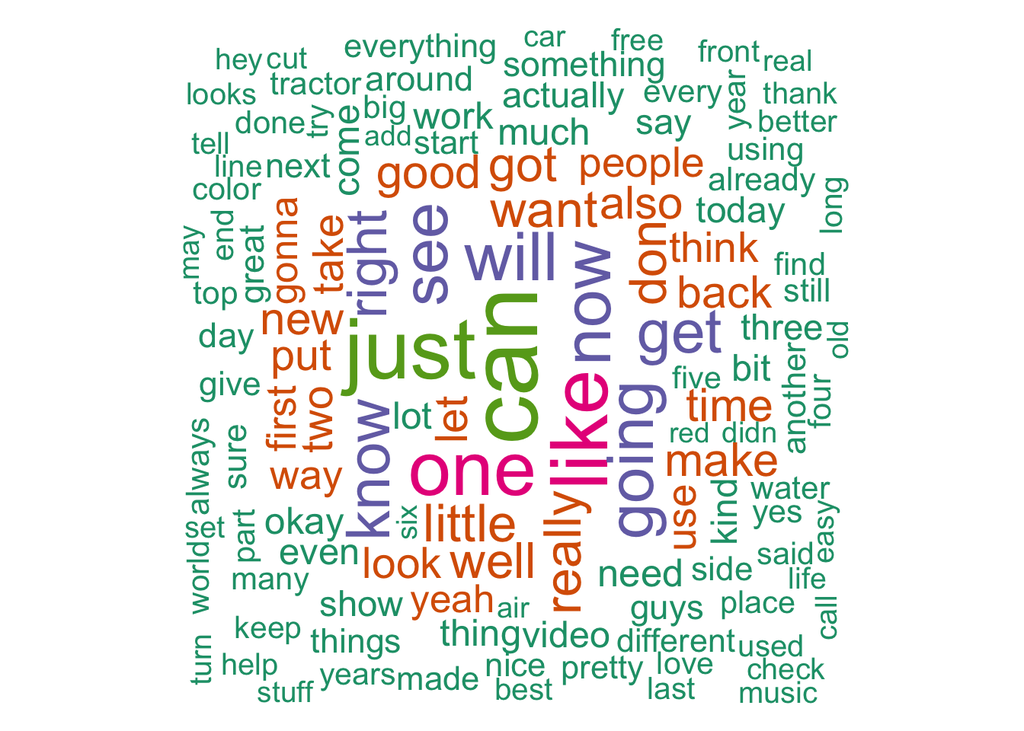

```r
file_df_business_industrial_freq <- strsplit(file_df_business_industrial, " ")
word_cloud_business_industrial <- unlist(file_df_business_industrial_freq)

wordcloud(word_cloud_business_industrial,min.freq = 50, max.words=200, random.order=F, rot.per=0.2, colors=brewer.pal(5, "Dark2"), scale=c(4,1))
```

## Wordcloud for Computers and Electronics category

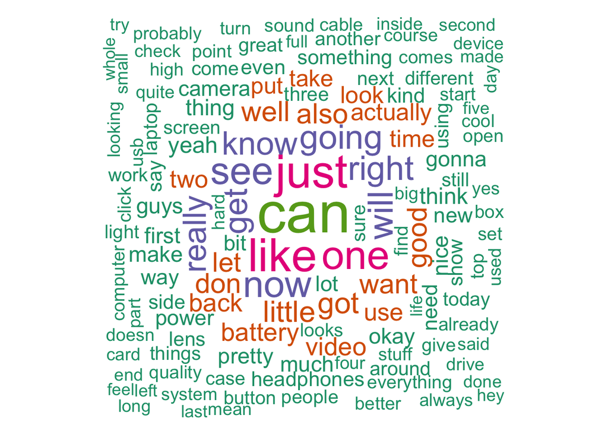

```r
file_df_computers_electronics_freq <- strsplit(file_df_computers_electronics, " ")
word_cloud_computers_elec <- unlist(file_df_computers_electronics_freq)

wordcloud(word_cloud_computers_elec,min.freq = 50, max.words=200, random.order=F, rot.per=0.2, colors=brewer.pal(5, "Dark2"), scale=c(4,1))
```

## Wordcloud for Food and Drink category

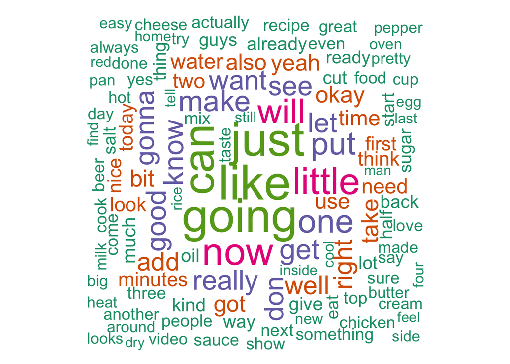

```r
file_df_food_drink_freq <- strsplit(file_df_food_drink, " ")
word_cloud_food_drink <- unlist(file_df_food_drink_freq)
#Option 1
wordcloud(word_cloud_food_drink,min.freq = 50, max.words=200, random.order=F, rot.per=0.2, colors=brewer.pal(5, "Dark2"), scale=c(4,1))
```

# References:

- WordCloud: https://acadgild.com/blog/text-mining-using-r
- Reading multiple files: https://cran.r-project.org/web/packages/readtext/vignettes/readtext_vignette.html